# Introduction

Inspired by the recent ship event at Baltimore Harbor, our group is interested in seeing how shipping of auto parts in the Baltimore Harbor affects the sale of vehicles. As most vehicles sold on the east coast come through the Baltimore Harbor, it would be interesting to see the link between imported car parts and the fluctuation in car sales. In addition, seeing how various regions in the US are impacted by the port trade at the harbor can give us insight into the price, location, and spread of vehicles throughout the mainland. Investigating such related trends is important as it can provide insight into the impact of inflation on car prices versus the actual supply and demand of parts.

# Data Collection

At this stage of our project, we will be looking for datasets related to our topic of car sales and the number of cars going through the Baltimore Harbor. For a topic such as this, we needed to find a detailed dataset that had information spanning years with numerous other features. Naturally, we turned to Kaggle and found a dataset on [Vehicle Sales](https://www.kaggle.com/datasets/syedanwarafridi/vehicle-sales-data) (“car_prices.csv”). This dataset has data on vehicular sales from 1982 to 2015, with a heavy emphasis on sales made between 2012 and 2015. In addition, it has sales data regarding in which state and at what date each car was sold.

In order to link the Vehicle Sales data to our claim, we needed to find a dataset on imports coming through the Baltimore Harbor. We were able to find a dataset for this on the Maryland Open Data Portal (“Maryland_Port_Administration_General_Cargo_20240609.csv”), with information on Auto Tons (tons of automobiles and automobile parts) and Ron/Roff tons (tons of automobiles). Furthermore, the Maryland port data had information dating back to 1998 until last month.

Our last dataset is from the [Bureau of Transportation Statistics](https://www.bts.gov/content/new-and-used-passenger-car-sales-and-leases-thousands-vehicles) ("Book(Sheet1).csv"), using their data to obtain more information on New and Used Cars. This dataset will help add additional data that we will use to make conclusions about trends between new cars and imported data from the Baltimore Harbor.

```python
# Imported libraries
import pandas as pd
import matplotlib.pyplot as plt
import sqlite3
import scipy
```

## Filtering Port Data

Loading in the Maryland Port Data

```python
maryland_port = pd.read_csv('Maryland_Port_Administration_General_Cargo_20240609.csv')
maryland_port
```

|  | Month | Container Tons | Auto Tons | Ro/Ro Tons (excl. autos) | Forest Products (Break Bulk) | Steel & other metals Break Bulk Tons | other Break Bulk Tons | Total General Cargo Tons | Import Loaded TEUs | Export Loaded TEUs | ... | Import Empty TEUs | Export Empty TEUs | Total Empty TEUs | Total TEUs | Total Containers | Import Auto Units | Export Auto Units | Total Auto UNITS | Import Ro/Ro Tons | Export Ro/Ro Tons |
| --- | --- | --- | --- | --- | --- | --- | --- | --- | --- | --- | --- | --- | --- | --- | --- | --- | --- | --- | --- | --- | --- |
| 0 | Jan 1998 | 360095 | 18386 | 32967 | 54189 | 15705 | 27515 | 508857 | 16051 | 17418 | ... | 3199 | 1436 | 4635 | 38104 | 23789 | 9452 | 2391 | 11843 | 22160 | 10807 |
| 1 | Feb 1998 | 359722 | 20085 | 37156 | 42726 | 13805 | 31879 | 505373 | 16228 | 16846 | ... | 3045 | 2056 | 5101 | 38175 | 23874 | 11206 | 1393 | 12599 | 23405 | 13751 |
| 2 | Mar 1998 | 377748 | 27610 | 57077 | 43910 | 10344 | 31001 | 547690 | 18577 | 18570 | ... | 5906 | 3525 | 9431 | 46578 | 28926 | 14570 | 2967 | 17537 | 40470 | 16607 |
| 3 | Apr 1998 | 377397 | 21900 | 56087 | 48180 | 5663 | 33094 | 542321 | 17777 | 18157 | ... | 2712 | 3070 | 5769 | 41703 | 25985 | 11715 | 2342 | 14057 | 39312 | 16775 |
| 4 | May 1998 | 382760 | 25824 | 40905 | 25530 | 4022 | 37509 | 516550 | 18178 | 17104 | ... | 2407 | 3242 | 5626 | 40908 | 26250 | 15081 | 1790 | 16871 | 28865 | 12040 |
| ... | ... | ... | ... | ... | ... | ... | ... | ... | ... | ... | ... | ... | ... | ... | ... | ... | ... | ... | ... | ... | ... |
| 311 | Dec 2023 | 737127 | 67874 | 105000 | 47981 | 773 | 14164 | 972919 | 47649 | 20006 | ... | 108 | 30165 | 30273 | 97928 | 57774 | 25891 | 6626 | 32517 | 81177 | 23823 |
| 312 | Jan 2024 | 716599 | 56332 | 92259 | 62397 | 199 | 12551 | 940337 | 48142 | 17612 | ... | 119 | 24554 | 24673 | 90427 | 53358 | 23214 | 5064 | 28278 | 73349 | 92259 |
| 313 | Feb 2024 | 727033 | 49220 | 86065 | 68283 | 2445 | 7767 | 940813 | 45641 | 19554 | ... | 140 | 27152 | 27292 | 92487 | 54106 | 17642 | 6174 | 23816 | 60863 | 25202 |
| 314 | Mar 2024 | 624526 | 56133 | 87613 | 24701 | 783 | 12104 | 805860 | 37996 | 16699 | ... | 6 | 20398 | 20404 | 75099 | 44793 | 22886 | 3538 | 26424 | 67431 | 20182 |
| 315 | Apr 2024 | 1822 | 0 | 0 | 0 | 0 | 0 | 1822 | 102 | 108 | ... | 0 | 1843 | 1843 | 2053 | 1386 | 0 | 0 | 0 | 0 | 0 |

316 rows × 21 columns

Filtering the Maryland Port Data for only the columns that we need

```python
maryland_final = pd.DataFrame()
maryland_final['DATE'] = maryland_port['Month']
maryland_final['Container Tons'] = maryland_port['Container Tons']
maryland_final['Auto Tons'] = maryland_port['Auto Tons']
maryland_final['Ro/Ro Tons (excl. autos)'] = maryland_port['Ro/Ro Tons (excl. autos)']
maryland_final['Import Auto Units'] = maryland_port['Import Auto Units']
maryland_final['Export Auto Units'] = maryland_port['Export Auto Units']
maryland_final['Import Ro/Ro Tons'] = maryland_port['Import Ro/Ro Tons']
maryland_final['Export Ro/Ro Tons'] = maryland_port['Export Ro/Ro Tons']
maryland_final
```

|  | DATE | Container Tons | Auto Tons | Ro/Ro Tons (excl. autos) | Import Auto Units | Export Auto Units | Import Ro/Ro Tons | Export Ro/Ro Tons |
| --- | --- | --- | --- | --- | --- | --- | --- | --- |
| 0 | Jan 1998 | 360095 | 18386 | 32967 | 9452 | 2391 | 22160 | 10807 |
| 1 | Feb 1998 | 359722 | 20085 | 37156 | 11206 | 1393 | 23405 | 13751 |
| 2 | Mar 1998 | 377748 | 27610 | 57077 | 14570 | 2967 | 40470 | 16607 |
| 3 | Apr 1998 | 377397 | 21900 | 56087 | 11715 | 2342 | 39312 | 16775 |
| 4 | May 1998 | 382760 | 25824 | 40905 | 15081 | 1790 | 28865 | 12040 |
| ... | ... | ... | ... | ... | ... | ... | ... | ... |
| 311 | Dec 2023 | 737127 | 67874 | 105000 | 25891 | 6626 | 81177 | 23823 |
| 312 | Jan 2024 | 716599 | 56332 | 92259 | 23214 | 5064 | 73349 | 92259 |
| 313 | Feb 2024 | 727033 | 49220 | 86065 | 17642 | 6174 | 60863 | 25202 |
| 314 | Mar 2024 | 624526 | 56133 | 87613 | 22886 | 3538 | 67431 | 20182 |
| 315 | Apr 2024 | 1822 | 0 | 0 | 0 | 0 | 0 | 0 |

316 rows × 8 columns

Loading in the Total Vehicles Sales data from the Federal Reserve Bank of St. Louis

```python
sale_df = pd.read_csv('TOTALSA.csv')
sale_df
```

|  | DATE | TOTALSA |
| --- | --- | --- |
| 0 | 1976-01-01 | 12.814 |
| 1 | 1976-02-01 | 13.340 |
| 2 | 1976-03-01 | 13.378 |
| 3 | 1976-04-01 | 13.223 |
| 4 | 1976-05-01 | 12.962 |
| ... | ... | ... |
| 576 | 2024-01-01 | 15.396 |
| 577 | 2024-02-01 | 16.098 |
| 578 | 2024-03-01 | 15.932 |
| 579 | 2024-04-01 | 16.295 |
| 580 | 2024-05-01 | 16.412 |

581 rows × 2 columns

Further filtering the Maryland Port and Total Vehicle Sales data to format the date column and enact a cutoff date.

We are implementing a cutoff date of December 2015 on the Maryland Port Data and Total Vehicle Sales data as the Car Prices dataframe only goes up to 2016.

```python
#formatting a consistent datetime
maryland_final['DATE'] = pd.to_datetime(maryland_final['DATE'], format='%b %Y')

# Define the cutoff date
cutoff_date = pd.to_datetime('Dec 2015', format='%b %Y')

# Filter the DataFrame to include only dates up to and including the cutoff date
filtered_df = maryland_final[maryland_final['DATE'] <= cutoff_date]

#formatting a consistent datetime for the total vehicle sales dataframe
sale_df["DATE"] = pd.to_datetime(sale_df['DATE'])

#mergining both the dataframes on the 'DATE' column
filtered_df = pd.merge(filtered_df, sale_df, on='DATE')
filtered_df
```

|  | DATE | Container Tons | Auto Tons | Ro/Ro Tons (excl. autos) | Import Auto Units | Export Auto Units | Import Ro/Ro Tons | Export Ro/Ro Tons | TOTALSA |
| --- | --- | --- | --- | --- | --- | --- | --- | --- | --- |
| 0 | 1998-01-01 | 360095 | 18386 | 32967 | 9452 | 2391 | 22160 | 10807 | 14.789 |
| 1 | 1998-02-01 | 359722 | 20085 | 37156 | 11206 | 1393 | 23405 | 13751 | 15.232 |
| 2 | 1998-03-01 | 377748 | 27610 | 57077 | 14570 | 2967 | 40470 | 16607 | 15.405 |
| 3 | 1998-04-01 | 377397 | 21900 | 56087 | 11715 | 2342 | 39312 | 16775 | 15.923 |
| 4 | 1998-05-01 | 382760 | 25824 | 40905 | 15081 | 1790 | 28865 | 12040 | 17.057 |
| ... | ... | ... | ... | ... | ... | ... | ... | ... | ... |
| 211 | 2015-08-01 | 600924 | 96205 | 69502 | 33750 | 16648 | 42129 | 27373 | 18.391 |
| 212 | 2015-09-01 | 516663 | 90904 | 48112 | 31161 | 15065 | 29224 | 18888 | 18.281 |
| 213 | 2015-10-01 | 555365 | 83458 | 53172 | 31355 | 12834 | 32730 | 20442 | 18.270 |
| 214 | 2015-11-01 | 588560 | 113544 | 56616 | 42013 | 18611 | 30781 | 25835 | 18.314 |
| 215 | 2015-12-01 | 554819 | 83590 | 48115 | 30114 | 13420 | 28705 | 19410 | 17.503 |

216 rows × 9 columns

## Cleaning and Exploring Car Sales Data

source: car_prices.csv

Loading in the Car Prices dataframe from our Kaggle Source

```python
car_prices = pd.read_csv('car_prices.csv')
car_prices
```

|  | year | make | model | trim | body | transmission | vin | state | condition | odometer | color | interior | seller | mmr | sellingprice | saledate |
| --- | --- | --- | --- | --- | --- | --- | --- | --- | --- | --- | --- | --- | --- | --- | --- | --- |
| 0 | 2015 | Kia | Sorento | LX | SUV | automatic | 5xyktca69fg566472 | ca | 5.0 | 16639.0 | white | black | kia motors america inc | 20500.0 | 21500.0 | Tue Dec 16 2014 12:30:00 GMT-0800 (PST) |
| 1 | 2015 | Kia | Sorento | LX | SUV | automatic | 5xyktca69fg561319 | ca | 5.0 | 9393.0 | white | beige | kia motors america inc | 20800.0 | 21500.0 | Tue Dec 16 2014 12:30:00 GMT-0800 (PST) |
| 2 | 2014 | BMW | 3 Series | 328i SULEV | Sedan | automatic | wba3c1c51ek116351 | ca | 45.0 | 1331.0 | gray | black | financial services remarketing (lease) | 31900.0 | 30000.0 | Thu Jan 15 2015 04:30:00 GMT-0800 (PST) |
| 3 | 2015 | Volvo | S60 | T5 | Sedan | automatic | yv1612tb4f1310987 | ca | 41.0 | 14282.0 | white | black | volvo na rep/world omni | 27500.0 | 27750.0 | Thu Jan 29 2015 04:30:00 GMT-0800 (PST) |
| 4 | 2014 | BMW | 6 Series Gran Coupe | 650i | Sedan | automatic | wba6b2c57ed129731 | ca | 43.0 | 2641.0 | gray | black | financial services remarketing (lease) | 66000.0 | 67000.0 | Thu Dec 18 2014 12:30:00 GMT-0800 (PST) |
| ... | ... | ... | ... | ... | ... | ... | ... | ... | ... | ... | ... | ... | ... | ... | ... | ... |
| 558832 | 2015 | Kia | K900 | Luxury | Sedan | NaN | knalw4d4xf6019304 | in | 45.0 | 18255.0 | silver | black | avis corporation | 35300.0 | 33000.0 | Thu Jul 09 2015 07:00:00 GMT-0700 (PDT) |
| 558833 | 2012 | Ram | 2500 | Power Wagon | Crew Cab | automatic | 3c6td5et6cg112407 | wa | 5.0 | 54393.0 | white | black | i -5 uhlmann rv | 30200.0 | 30800.0 | Wed Jul 08 2015 09:30:00 GMT-0700 (PDT) |
| 558834 | 2012 | BMW | X5 | xDrive35d | SUV | automatic | 5uxzw0c58cl668465 | ca | 48.0 | 50561.0 | black | black | financial services remarketing (lease) | 29800.0 | 34000.0 | Wed Jul 08 2015 09:30:00 GMT-0700 (PDT) |
| 558835 | 2015 | Nissan | Altima | 2.5 S | sedan | automatic | 1n4al3ap0fc216050 | ga | 38.0 | 16658.0 | white | black | enterprise vehicle exchange / tra / rental / t... | 15100.0 | 11100.0 | Thu Jul 09 2015 06:45:00 GMT-0700 (PDT) |
| 558836 | 2014 | Ford | F-150 | XLT | SuperCrew | automatic | 1ftfw1et2eke87277 | ca | 34.0 | 15008.0 | gray | gray | ford motor credit company llc pd | 29600.0 | 26700.0 | Thu May 28 2015 05:30:00 GMT-0700 (PDT) |

558837 rows × 16 columns

Filtering our dataframe to only hold the columns that we need and dropping the misssing rows

```python
cpf = pd.DataFrame()
cpf['makeyear']=car_prices['year']
cpf['sellingprice']=car_prices['sellingprice']
cpf['saledate'] = car_prices['saledate']
cpf['mmr']=car_prices['mmr']
cpf['state']=car_prices['state']

# Dropping the missing rows of data in the dataframe
missing_rows = cpf[cpf.isna().any(axis=1)]
cpf.dropna(inplace=True)

cpf
```

|  | makeyear | sellingprice | saledate | mmr | state |
| --- | --- | --- | --- | --- | --- |
| 0 | 2015 | 21500.0 | Tue Dec 16 2014 12:30:00 GMT-0800 (PST) | 20500.0 | ca |
| 1 | 2015 | 21500.0 | Tue Dec 16 2014 12:30:00 GMT-0800 (PST) | 20800.0 | ca |
| 2 | 2014 | 30000.0 | Thu Jan 15 2015 04:30:00 GMT-0800 (PST) | 31900.0 | ca |
| 3 | 2015 | 27750.0 | Thu Jan 29 2015 04:30:00 GMT-0800 (PST) | 27500.0 | ca |
| 4 | 2014 | 67000.0 | Thu Dec 18 2014 12:30:00 GMT-0800 (PST) | 66000.0 | ca |
| ... | ... | ... | ... | ... | ... |
| 558832 | 2015 | 33000.0 | Thu Jul 09 2015 07:00:00 GMT-0700 (PDT) | 35300.0 | in |
| 558833 | 2012 | 30800.0 | Wed Jul 08 2015 09:30:00 GMT-0700 (PDT) | 30200.0 | wa |
| 558834 | 2012 | 34000.0 | Wed Jul 08 2015 09:30:00 GMT-0700 (PDT) | 29800.0 | ca |
| 558835 | 2015 | 11100.0 | Thu Jul 09 2015 06:45:00 GMT-0700 (PDT) | 15100.0 | ga |
| 558836 | 2014 | 26700.0 | Thu May 28 2015 05:30:00 GMT-0700 (PDT) | 29600.0 | ca |

558799 rows × 5 columns

Further formatting our data's saledate column to match the other dataframes

```python
# Function to parse each saledate value into
# year-month-day
def month_year(date):
  parts = date.split()
  month = parts[1]
  day = parts[2]
  year = parts[3]
  return month + ' ' + day + ' ' + year

cpf['saledate'] = cpf['saledate'].apply(month_year)

# Apply a standardized to_datetime to match the other dataframes
cpf['saledate'] = pd.to_datetime(cpf['saledate'], format = '%b %d %Y')

cpf
```

|  | makeyear | sellingprice | saledate | mmr | state |
| --- | --- | --- | --- | --- | --- |
| 0 | 2015 | 21500.0 | 2014-12-16 | 20500.0 | ca |
| 1 | 2015 | 21500.0 | 2014-12-16 | 20800.0 | ca |
| 2 | 2014 | 30000.0 | 2015-01-15 | 31900.0 | ca |
| 3 | 2015 | 27750.0 | 2015-01-29 | 27500.0 | ca |
| 4 | 2014 | 67000.0 | 2014-12-18 | 66000.0 | ca |
| ... | ... | ... | ... | ... | ... |
| 558832 | 2015 | 33000.0 | 2015-07-09 | 35300.0 | in |
| 558833 | 2012 | 30800.0 | 2015-07-08 | 30200.0 | wa |
| 558834 | 2012 | 34000.0 | 2015-07-08 | 29800.0 | ca |
| 558835 | 2015 | 11100.0 | 2015-07-09 | 15100.0 | ga |
| 558836 | 2014 | 26700.0 | 2015-05-28 | 29600.0 | ca |

558799 rows × 5 columns

## Exploratory Analysis & Data Visualization

In this section of the project, we will be visualizing and graphing our data using Matplot and Seaborn libraries. In addition, we will attempt to perform statistical analyses on our data to test our claims and find real-world conclusions based on the results. Essentially, we will be looking to identify trends and affirm our beliefs through the statistical methods in this section.

Source: Maryland Port Administration and Federal Reserve Bank of St. Louis

For this test, we are looking to check if there is a correlation between the import of auto tons into the Baltimore Harbor and the Total Car Sales across the country. We have plotted two line graphs displaying total vehicle sales and auto tons versus the date. With the comparison of these graphs we can see that when the number of auto tons decreases, total vehicle sales tend to decrease as well. We can see this occur clearly around 2008 (economic recession) on the graph where both values decrease and gradually increase simultaneously. That being said, our null hypothesis is that there is **NOT** a strong correlation between the number of Auto Tons into the Baltimore Harbor and Total Vehicle Sales across the U.S. Our alternative hypothesis is that there is a **STRONG** correlation between the number of Auto Tons into the Baltimore Harbor and Total Vehicle Sales across the U.S.

Plotting the Date versus Auto Tons line graph

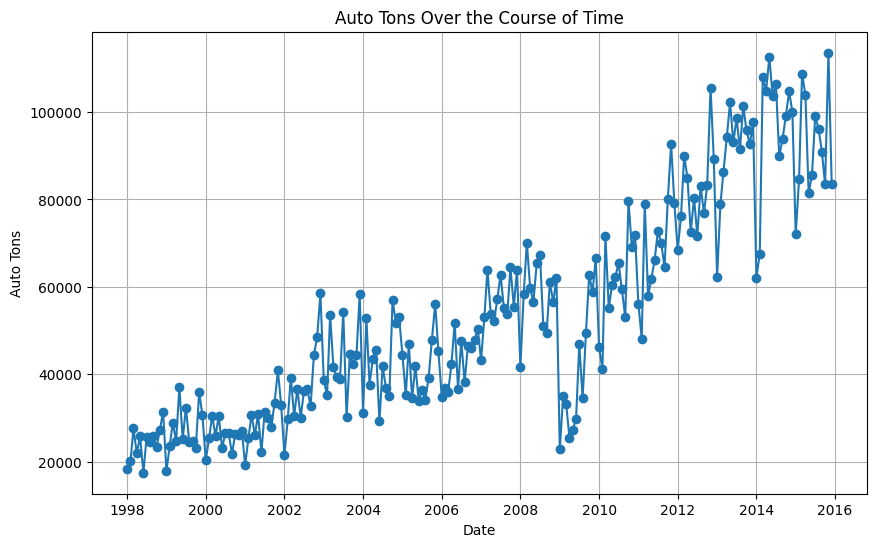

```python
# Plot the data
plt.figure(figsize=(10, 6))
plt.plot(filtered_df['DATE'], filtered_df['Auto Tons'], marker='o')
plt.xlabel('Date')
plt.ylabel('Auto Tons')
plt.title('Auto Tons Over the Course of Time')
plt.grid(True)
plt.show()
```

Plotting the Date versus Total Vehicle Sales line graph

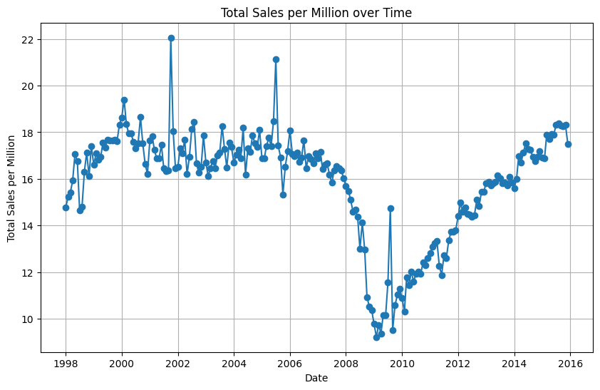

```python
# Plot the data
plt.figure(figsize=(10, 6))
plt.plot(filtered_df['DATE'], filtered_df['TOTALSA'], marker='o')
plt.xlabel('Date')
plt.ylabel('Total Sales per Million')
plt.title('Total Sales per Million over Time')
plt.grid(True)
plt.show()
```

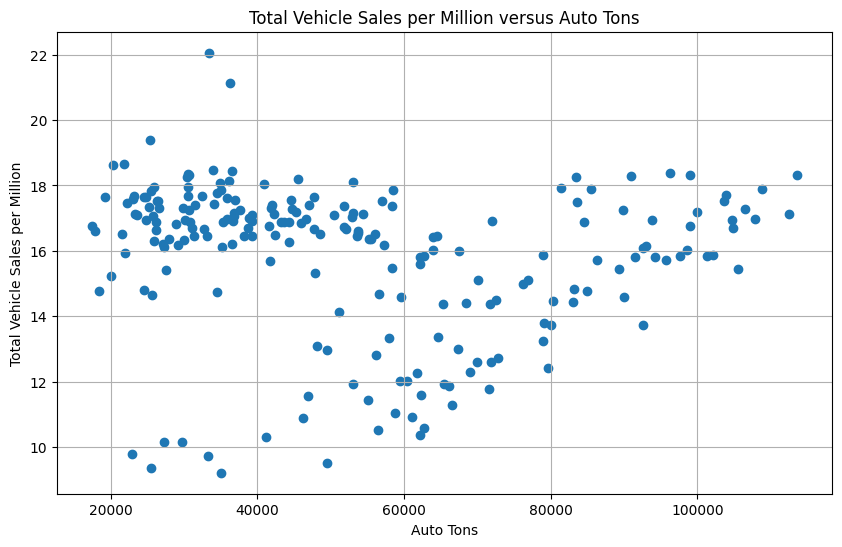

```python
# Plot the data
plt.figure(figsize=(10, 6))
plt.scatter(filtered_df['Auto Tons'], filtered_df['TOTALSA'], marker='o')
plt.xlabel('Auto Tons')
plt.ylabel('Total Vehicle Sales per Million')
plt.title('Total Vehicle Sales per Million versus Auto Tons')
plt.grid(True)
plt.show()
```

Conducting the Linear Regression and Spearman correlations to see if there is a relationship between Auto Tons and Total Vehicle Sales

```python
res = scipy.stats.linregress(filtered_df['Auto Tons'], filtered_df['TOTALSA'])
print(f"R-squared: {res.rvalue**2:.3f}")
```

```
R-squared: 0.014
```

```python
res = scipy.stats.spearmanr(filtered_df['Auto Tons'], filtered_df['TOTALSA'])
print(f"Spearman correlation coefficient: {res.statistic:.3f}")
```

```
Spearman correlation coefficient: -0.256
```

Conclusion: In our third graph for this test, we created a scatter plot of the auto tons versus the total vehicle sales. This graph depicted a relationship between the data that was contrary to our beliefs. After running two separate regressions (Linear Reg and Spearman), we found that there indeed was a low correlation between the two variables with an R2 score of 0.014 and a Spearman value of -0.256. These values indicate a weak and almost non-existent relationship between Auto Tons and Total Vehicle Sales. This conclusion of failing to reject the null hypothesis was rather surprising considering the similarity of both the values’ trends at pivotal points.

## Second Test: Comparing Sales Data and Selling Price Based on Region of America

West Coast vs. Middle vs. East Coast

For this test, we are comparing selling prices of cars based on the region of America to see if vehicle prices are increasing from east to west. If this is true, then it will affirm our assumption that a majority of cars imported to the U.S. come from the Baltimore Harbor, which is located on the East Coast.

Filtered our car sales data frame to consist of cars that were sold in the mainland U.S. excluding states like Hawaii and Puerto Rico.

```python
arr = ['3vwd17aj4fm201708','3vwd17aj2fm258506', '3vwd17aj3fm276741', '3vwd17aj2fm285365',
       '3vwd17aj0fm227318', '3vwd17aj6fm218641', '3vwd17aj7fm223475',
       '3vwd17aj5fm297123', '3vwd17aj5fm219943', '3vwd17aj9fm219766',
       '3vwd17aj3fm259017', '3vwd17aj5fm206111', '3vwd17aj5fm273601',
       '3vwd17aj5fm221322', '3vwd17aj5fm268964', '3vwd17aj6fm231972',
       '3vwd17aj7fm222388', '3vwd17aj7fm218440', '3vwd17ajxfm315938',
       '3vwd17aj7fm229552', '3vwd17aj8fm298895', '3vwd17aj4fm236636',
       '3vwd17aj5fm225953', '3vwd17aj7fm326640', '3vwd17aj8fm239622',
       '3vwd17aj2fm261566', 'qc', 'ns', 'on', 'pr', 'hi', 'ab']

for state in arr:
  cpf = cpf[cpf['state'] != state]

states = cpf['state'].unique()
states
```

```
array(['ca', 'tx', 'pa', 'mn', 'az', 'wi', 'tn', 'md', 'fl', 'ne', 'nj',
       'nv', 'oh', 'mi', 'ga', 'va', 'sc', 'nc', 'in', 'il', 'co', 'ut',
       'mo', 'ny', 'ma', 'or', 'la', 'wa', 'ok', 'ms', 'nm', 'al'],
      dtype=object)
```

Grouped each state by region in the U.S.A

```python
west_coast = ['ca', 'az', 'nv', 'ut', 'or', 'wa', 'nm']
middle = ['tx', 'mn', 'wi', 'ne', 'mi', 'in', 'il', 'mo', 'la', 'ok']
east_coast = ['pa', 'tn', 'md', 'fl', 'nj', 'oh', 'ga', 'va', 'sc', 'nc', 'co', 'ny', 'ma', 'ms', 'al']

#created arrays of vehicle selling prices based on region
west_coast_sales = cpf[cpf['state'].isin(west_coast)]['sellingprice']
east_coast_sales = cpf[cpf['state'].isin(east_coast)]['sellingprice']
middle_sales = cpf[cpf['state'].isin(middle)]['sellingprice']
```

Afterward, we created a column mapping each state to a particular region: West Coast, middle, or East Coast.

```python
cpf['Coast'] = cpf['state'].map({'ca': 'west_coast', 'az': 'west_coast', 'nv': 'west_coast', 'ut': 'west_coast', 'or': 'west_coast', 'wa': 'west_coast', 'nm': 'west_coast',
                               'tx': 'middle', 'mn': 'middle', 'wi': 'middle', 'ne': 'middle', 'mi': 'middle', 'in': 'middle', 'il': 'middle', 'mo': 'middle', 'la': 'middle', 'ok': 'middle',
                                'pa': 'east_coast', 'tn': 'east_coast', 'md': 'east_coast', 'fl': 'east_coast', 'nj': 'east_coast', 'oh': 'east_coast', 'ga': 'east_coast', 'va': 'east_coast', 'sc': 'east_coast', 'nc': 'east_coast', 'co': 'east_coast', 'ny': 'east_coast', 'ma': 'east_coast', 'ms': 'east_coast', 'al': 'east_coast'})
```

Visualizing each region's distribution of selling price through a multi box-whisker plot

As per this plot there are many outliers for each region, but we chose to keep them as they may be in the hundreds or thousands considering the large number of data points within the set.

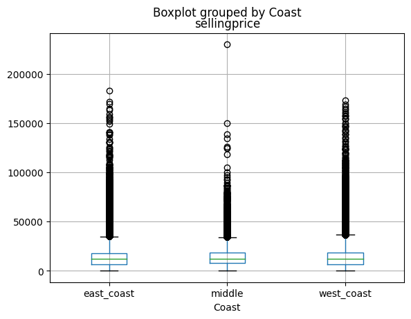

```python
cpf.boxplot(column='sellingprice', by='Coast')
```

Printing and Visualizing the means of each region's selling price data

```python
print(f"West Coast mean: {west_coast_sales.mean()}")
print(f"Middle mean: {middle_sales.mean()}")
print(f"East Coast mean: {east_coast_sales.mean()}")
```

```
West Coast mean: 14203.39257829217
Middle mean: 13791.606715801707
East Coast mean: 13342.470362116635
```

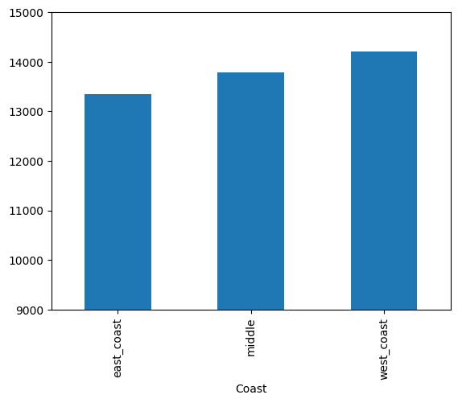

```python
# Displaying a bar plot of each region's mean
means = cpf.groupby('Coast')['sellingprice'].mean()
means.plot(kind='bar', ylim=(9000, 15000))
```

Conducting the ANOVA test on all of the regions selling prices

Our null hypothesis is that there is **NO** significant difference in the mean value of the selling price between the three different regions of car sales data. On the other hand, our alternative hypothesis is that there is a **SIGNIFICANT** difference in the mean value of the selling price between the three different regions of car sales data.

```python
import scipy
# Perform the one-way ANOVA
res = scipy.stats.f_oneway(west_coast_sales, east_coast_sales, middle_sales)

# Print the results
print("ANOVA Test Result:")
print(f"P-value: {res.pvalue}")
```

```
ANOVA Test Result:
P-value: 4.284099116986088e-146
```

```python
from scipy.stats import tukey_hsd

#Perform thee Turkey HSD post-hoc test
res = tukey_hsd(west_coast_sales, east_coast_sales, middle_sales)
print(res)
```

```
Tukey's HSD Pairwise Group Comparisons (95.0% Confidence Interval)
Comparison  Statistic  p-value  Lower CI  Upper CI
 (0 - 1)    860.922     0.000   779.435   942.410
 (0 - 2)    411.786     0.000   317.087   506.484
 (1 - 0)   -860.922     0.000  -942.410  -779.435
 (1 - 2)   -449.136     0.000  -524.406  -373.867
 (2 - 0)   -411.786     0.000  -506.484  -317.087
 (2 - 1)    449.136     0.000   373.867   524.406
```

Conclusion: In comparing the three different groups using the ANOVA, we were able to reject our null hypothesis with a p-value of 4.284099116986088e-146, which is close to zero. Considering this, we decided to dig deeper into the data and conduct a post hoc test using the Turkey HSD method in Scipy. In doing so, the test resulted in rejecting the null hypothesis for all inter-group differences, further asserting our alternative hypothesis. By rejecting the null hypothesis, we have concluded that there is a significant increase in vehicle prices moving from the East Coast to the Middle to the West Coast. This can be attributed to our original assumption that a majority of the influx of cars go through the Baltimore port which can be backed up by the difference in the selling price of cars between the East Coast and West Coast.

## Third Test: Comparing New Cars and Used Cars Over Time

```python
AvgUsedCar = pd.read_csv('CUSR0000SETA02.csv')
AvgNewCar = pd.read_csv('CUUR0000SETA01.csv')
print(AvgUsedCar)
print(AvgNewCar)

# Filtering to get rid of missing data
AvgNewCar = AvgNewCar[AvgNewCar['CUUR0000SETA01'] != '.']
AvgUsedCar = AvgUsedCar[AvgUsedCar['CUSR0000SETA02'] != '.']

# functions to return the average price of a new car and used car
def CPItoAverageCost_New(CPI):
  CPI2 = float(CPI)
  avg_price=(CPI2/100)*9000
  return avg_price

def CPItoAverageCost_Used(CPI):
  CPI2 = float(CPI)
  avg_price=(CPI2/100)*5000
  return avg_price

#apply the functionss on the columns to obtain a new car and used car accurate cost
AvgUsedCar['Used'] = AvgUsedCar['CUSR0000SETA02'].apply(CPItoAverageCost_Used)
AvgNewCar['New'] = AvgNewCar['CUUR0000SETA01'].apply(CPItoAverageCost_New)

AvgCar = pd.merge(AvgNewCar, AvgUsedCar, on='DATE')
AvgCar
```

```
           DATE  CUSR0000SETA02
0    1953-01-01          28.700
1    1953-02-01          28.700
2    1953-03-01          28.400
3    1953-04-01          28.300
4    1953-05-01          27.500
..          ...             ...
852  2024-01-01         184.150
853  2024-02-01         185.105
854  2024-03-01         183.042
855  2024-04-01         180.522
856  2024-05-01         181.614

[857 rows x 2 columns]
           DATE CUUR0000SETA01
0    1947-03-01         33.300
1    1947-04-01              .
2    1947-05-01              .
3    1947-06-01         33.400
4    1947-07-01              .
..          ...            ...
922  2024-01-01        178.595
923  2024-02-01        178.592
924  2024-03-01        178.247
925  2024-04-01        178.250
926  2024-05-01        177.958

[927 rows x 2 columns]
```

|  | DATE | CUUR0000SETA01 | New | CUSR0000SETA02 | Used |
| --- | --- | --- | --- | --- | --- |
| 0 | 1953-01-01 | 47.300 | 4257.00 | 28.700 | 1435.00 |
| 1 | 1953-02-01 | 47.400 | 4266.00 | 28.700 | 1435.00 |
| 2 | 1953-03-01 | 47.300 | 4257.00 | 28.400 | 1420.00 |
| 3 | 1953-04-01 | 47.200 | 4248.00 | 28.300 | 1415.00 |
| 4 | 1953-05-01 | 47.300 | 4257.00 | 27.500 | 1375.00 |
| ... | ... | ... | ... | ... | ... |
| 852 | 2024-01-01 | 178.595 | 16073.55 | 184.150 | 9207.50 |
| 853 | 2024-02-01 | 178.592 | 16073.28 | 185.105 | 9255.25 |
| 854 | 2024-03-01 | 178.247 | 16042.23 | 183.042 | 9152.10 |
| 855 | 2024-04-01 | 178.250 | 16042.50 | 180.522 | 9026.10 |
| 856 | 2024-05-01 | 177.958 | 16016.22 | 181.614 | 9080.70 |

857 rows × 5 columns

Loading in another dataset from the BTS for information gaps

```python
CarDataComplete = pd.read_csv('Book(Sheet1).csv')
CarDataComplete

CDCT = CarDataComplete.transpose()
CDCT
```

|  | 0 | 1 | 2 | 3 | 4 | 5 | 6 | 7 | 8 | 9 | ... | 31 | 32 | 33 | 34 | 35 | 36 | 37 | 38 | 39 | 40 |
| --- | --- | --- | --- | --- | --- | --- | --- | --- | --- | --- | --- | --- | --- | --- | --- | --- | --- | --- | --- | --- | --- |
| Table 1-17: New and Used Passenger Car and Light Truck Sales (thousands of vehicles) | NaN | Total, vehicle sales and leases | New vehicle sales and leasesa | Passenger cars | Light trucks | New vehicle sales | Passenger cars | Light trucks | New vehicle leases | Passenger cars | ... | Leases include private and retail figures, cor... | Edmunds sales include vehicles up to class 5 w... | NaN | SOURCES | New vehicle sales and leases: | 1990-2009: CNW Research, personal communicatio... | 2010-22: Edmunds, personal communication, May ... | Used vehicle sales and average price: | 1990-2009: Manheim Consulting, personal commun... | 2010-19: Edmunds, Used Vehicle Report, availab... |
| Unnamed: 1 | 1990 | 51,420 | 13,890 | 9,300 | 4,590 | 12,826 | 8,320 | 4,506 | 1,064 | 980 | ... | NaN | NaN | NaN | NaN | NaN | NaN | NaN | NaN | NaN | NaN |
| Unnamed: 2 | 1991 | 49,650 | 12,360 | 8,200 | 4,160 | 11,106 | 7,080 | 4,026 | 1,254 | 1,120 | ... | NaN | NaN | NaN | NaN | NaN | NaN | NaN | NaN | NaN | NaN |
| Unnamed: 3 | 1992 | 49,420 | 12,470 | 8,200 | 4,270 | 10,748 | 6,870 | 3,878 | 1,722 | 1,330 | ... | NaN | NaN | NaN | NaN | NaN | NaN | NaN | NaN | NaN | NaN |
| Unnamed: 4 | 1993 | 51,567 | 13,510 | 8,500 | 5,010 | 11,028 | 6,780 | 4,248 | 2,482 | 1,720 | ... | NaN | NaN | NaN | NaN | NaN | NaN | NaN | NaN | NaN | NaN |
| Unnamed: 5 | 1994 | 55,061 | 14,920 | 9,000 | 5,920 | 11,696 | 6,770 | 4,926 | 3,224 | 2,230 | ... | NaN | NaN | NaN | NaN | NaN | NaN | NaN | NaN | NaN | NaN |
| Unnamed: 6 | 1995 | 56,458 | 14,700 | 8,500 | 6,200 | 11,320 | 6,270 | 5,050 | 3,380 | 2,230 | ... | NaN | NaN | NaN | NaN | NaN | NaN | NaN | NaN | NaN | NaN |
| Unnamed: 7 | 1996 | 55,701 | 14,900 | 8,200 | 6,700 | 11,120 | 5,850 | 5,270 | 3,780 | 2,350 | ... | NaN | NaN | NaN | NaN | NaN | NaN | NaN | NaN | NaN | NaN |
| Unnamed: 8 | 1997 | 56,337 | 15,100 | 8,200 | 6,900 | 11,260 | 5,890 | 5,370 | 3,840 | 2,310 | ... | NaN | NaN | NaN | NaN | NaN | NaN | NaN | NaN | NaN | NaN |
| Unnamed: 9 | 1998 | 56,401 | 15,560 | 8,200 | 7,360 | 11,050 | 5,410 | 5,640 | 4,510 | 2,790 | ... | NaN | NaN | NaN | NaN | NaN | NaN | NaN | NaN | NaN | NaN |
| Unnamed: 10 | 1999 | 57,699 | 16,960 | 8,750 | 8,210 | 11,500 | 6,090 | 5,410 | 5,460 | 2,660 | ... | NaN | NaN | NaN | NaN | NaN | NaN | NaN | NaN | NaN | NaN |
| Unnamed: 11 | 2000 | 59,030 | 17,410 | 9,000 | 8,410 | 12,120 | 6,290 | 5,830 | 5,290 | 2,710 | ... | NaN | NaN | NaN | NaN | NaN | NaN | NaN | NaN | NaN | NaN |
| Unnamed: 12 | 2001 | 59,874 | 17,250 | 8,550 | 8,700 | 12,690 | 6,040 | 6,650 | 4,560 | 2,510 | ... | NaN | NaN | NaN | NaN | NaN | NaN | NaN | NaN | NaN | NaN |
| Unnamed: 13 | 2002 | 59,825 | 16,800 | 8,300 | 8,500 | 12,852 | 6,350 | 6,502 | 3,948 | 1,950 | ... | NaN | NaN | NaN | NaN | NaN | NaN | NaN | NaN | NaN | NaN |
| Unnamed: 14 | 2003 | 60,242 | 16,670 | 8,050 | 8,620 | 13,268 | 6,240 | 7,028 | 3,402 | 1,810 | ... | NaN | NaN | NaN | NaN | NaN | NaN | NaN | NaN | NaN | NaN |
| Unnamed: 15 | 2004 | 59,395 | 16,850 | 8,220 | 8,630 | 13,406 | 6,340 | 7,066 | 3,444 | 1,880 | ... | NaN | NaN | NaN | NaN | NaN | NaN | NaN | NaN | NaN | NaN |
| Unnamed: 16 | 2005 | 61,128 | 16,990 | 8,020 | 8,970 | 13,492 | 6,098 | 7,394 | 3,498 | 1,922 | ... | NaN | NaN | NaN | NaN | NaN | NaN | NaN | NaN | NaN | NaN |
| Unnamed: 17 | 2006 | 59,026 | 16,460 | 8,150 | 8,310 | 12,742 | 6,182 | 6,560 | 3,718 | 1,968 | ... | NaN | NaN | NaN | NaN | NaN | NaN | NaN | NaN | NaN | NaN |
| Unnamed: 18 | 2007 | 57,649 | 16,230 | 8,060 | 8,170 | 12,317 | 6,177 | 6,140 | 3,913 | 1,883 | ... | NaN | NaN | NaN | NaN | NaN | NaN | NaN | NaN | NaN | NaN |
| Unnamed: 19 | 2008 | 49,830 | 13,300 | 7,110 | 6,190 | 10,285 | 5,387 | 4,898 | 3,015 | 1,723 | ... | NaN | NaN | NaN | NaN | NaN | NaN | NaN | NaN | NaN | NaN |
| Unnamed: 20 | 2009 | 46,042 | 10,550 | 5,850 | 4,700 | 8,047 | 4,507 | 3,540 | 2,503 | 1,343 | ... | NaN | NaN | NaN | NaN | NaN | NaN | NaN | NaN | NaN | NaN |
| Unnamed: 21 | 2010 | 48,500 | 11,589 | 5,724 | 5,865 | 9,610 | 4,515 | 5,095 | 1,979 | 1,209 | ... | NaN | NaN | NaN | NaN | NaN | NaN | NaN | NaN | NaN | NaN |
| Unnamed: 22 | 2011 | 49,699 | 12,778 | 6,128 | 6,650 | 10,521 | 4,812 | 5,709 | 2,256 | 1,316 | ... | NaN | NaN | NaN | NaN | NaN | NaN | NaN | NaN | NaN | NaN |
| Unnamed: 23 | 2012 | 52,077 | 14,494 | 7,245 | 7,249 | 11,923 | 5,692 | 6,231 | 2,571 | 1,553 | ... | NaN | NaN | NaN | NaN | NaN | NaN | NaN | NaN | NaN | NaN |
| Unnamed: 24 | 2013 | 51,368 | 15,592 | 7,583 | 8,010 | 12,364 | 5,712 | 6,653 | 3,228 | 1,871 | ... | NaN | NaN | NaN | NaN | NaN | NaN | NaN | NaN | NaN | NaN |
| Unnamed: 25 | 2014 | 52,758 | 16,516 | 7,695 | 8,821 | 12,944 | 5,751 | 7,193 | 3,572 | 1,944 | ... | NaN | NaN | NaN | NaN | NaN | NaN | NaN | NaN | NaN | NaN |
| Unnamed: 26 | 2015 | 54,727 | 17,472 | 7,532 | 9,940 | 13,473 | 5,559 | 7,914 | 3,999 | 1,973 | ... | NaN | NaN | NaN | NaN | NaN | NaN | NaN | NaN | NaN | NaN |
| Unnamed: 27 | 2016 | 56,162 | 17,559 | 6,882 | 10,677 | 13,251 | 4,981 | 8,270 | 4,308 | 1,901 | ... | NaN | NaN | NaN | NaN | NaN | NaN | NaN | NaN | NaN | NaN |
| Unnamed: 28 | 2017 | 56,435 | 17,231 | 6,104 | 11,127 | 13,048 | 4,479 | 8,568 | 4,183 | 1,624 | ... | NaN | NaN | NaN | NaN | NaN | NaN | NaN | NaN | NaN | NaN |
| Unnamed: 29 | 2018 | 57,545 | 17,312 | 5,326 | 11,986 | 13,077 | 4,005 | 9,072 | 4,234 | 1,320 | ... | NaN | NaN | NaN | NaN | NaN | NaN | NaN | NaN | NaN | NaN |
| Unnamed: 30 | 2019 | 57,865 | 17,059 | 4,733 | 12,326 | 12,817 | 3,506 | 9,311 | 4,242 | 1,227 | ... | NaN | NaN | NaN | NaN | NaN | NaN | NaN | NaN | NaN | NaN |
| Unnamed: 31 | 2020 | U | 14,555 | 3,426 | 11,129 | 11,014 | 2,511 | 8,502 | 3,541 | 915 | ... | NaN | NaN | NaN | NaN | NaN | NaN | NaN | NaN | NaN | NaN |
| Unnamed: 32 | 2021 | U | 15,016 | 3,326 | 11,690 | 11,741 | 2,533 | 9,208 | 3,275 | 793 | ... | NaN | NaN | NaN | NaN | NaN | NaN | NaN | NaN | NaN | NaN |
| Unnamed: 33 | 2022 | U | 13,782 | 2,895 | 10,887 | 11,522 | 2,453 | 9,069 | 2,260 | 442 | ... | NaN | NaN | NaN | NaN | NaN | NaN | NaN | NaN | NaN | NaN |

34 rows × 41 columns

```python
# Filtring the previous dataset and loading in only the columns that we need

w=pd.DataFrame()
w['DATE'] = CarDataComplete.iloc[0]
w = w.iloc[1:]
w["DATE"] = w["DATE"].astype(int)
w['new sales'] = CarDataComplete.iloc[5]
w['used sales'] = CarDataComplete.iloc[11]
w
```

|  | DATE | new sales | used sales |
| --- | --- | --- | --- |
| Unnamed: 1 | 1990 | 12,826 | 37,530 |
| Unnamed: 2 | 1991 | 11,106 | 37,290 |
| Unnamed: 3 | 1992 | 10,748 | 36,950 |
| Unnamed: 4 | 1993 | 11,028 | 38,057 |
| Unnamed: 5 | 1994 | 11,696 | 40,141 |
| Unnamed: 6 | 1995 | 11,320 | 41,758 |
| Unnamed: 7 | 1996 | 11,120 | 40,801 |
| Unnamed: 8 | 1997 | 11,260 | 41,237 |
| Unnamed: 9 | 1998 | 11,050 | 40,841 |
| Unnamed: 10 | 1999 | 11,500 | 40,739 |
| Unnamed: 11 | 2000 | 12,120 | 41,620 |
| Unnamed: 12 | 2001 | 12,690 | 42,624 |
| Unnamed: 13 | 2002 | 12,852 | 43,025 |
| Unnamed: 14 | 2003 | 13,268 | 43,572 |
| Unnamed: 15 | 2004 | 13,406 | 42,545 |
| Unnamed: 16 | 2005 | 13,492 | 44,138 |
| Unnamed: 17 | 2006 | 12,742 | 42,566 |
| Unnamed: 18 | 2007 | 12,317 | 41,419 |
| Unnamed: 19 | 2008 | 10,285 | 36,530 |
| Unnamed: 20 | 2009 | 8,047 | 35,492 |
| Unnamed: 21 | 2010 | 9,610 | 36,911 |
| Unnamed: 22 | 2011 | 10,521 | 36,921 |
| Unnamed: 23 | 2012 | 11,923 | 37,583 |
| Unnamed: 24 | 2013 | 12,364 | 35,776 |
| Unnamed: 25 | 2014 | 12,944 | 36,242 |
| Unnamed: 26 | 2015 | 13,473 | 37,255 |
| Unnamed: 27 | 2016 | 13,251 | 38,602 |
| Unnamed: 28 | 2017 | 13,048 | 39,204 |
| Unnamed: 29 | 2018 | 13,077 | 40,233 |
| Unnamed: 30 | 2019 | 12,817 | 40,807 |
| Unnamed: 31 | 2020 | 11,014 | U |
| Unnamed: 32 | 2021 | 11,741 | U |
| Unnamed: 33 | 2022 | 11,522 | U |

```python
# function to return year in integer
def getYear(date):
  return date.year
```

Convert the date in the dataframe to an integer format and apply an aggregate function of sum.

Then perform a merge on the Maryland Port Data to obtain a table of comparison on new and used cars versus import auto tons.

```python
# new dataframe importing columns from the Maryland Port Data
tempfdf = pd.DataFrame()
tempfdf['DATE']= filtered_df['DATE']
tempfdf['Import Auto Units'] = filtered_df['Import Auto Units']


# Formatting date
tempfdf['DATE'] = tempfdf['DATE'].apply(getYear)
tempfdf = tempfdf.groupby('DATE').sum()

#Merging dataframes
merged_df = pd.merge(tempfdf, w, on='DATE')
print(merged_df)
```

```
    DATE  Import Auto Units new sales used sales
0   1998             144268    11,050     40,841
1   1999             176509    11,500     40,739
2   2000             175621    12,120     41,620
3   2001             202938    12,690     42,624
4   2002             255230    12,852     43,025
5   2003             286598    13,268     43,572
6   2004             281298    13,406     42,545
7   2005             261895    13,492     44,138
8   2006             245517    12,742     42,566
9   2007             238287    12,317     41,419
10  2008             239498    10,285     36,530
11  2009             192196     8,047     35,492
12  2010             271441     9,610     36,911
13  2011             280326    10,521     36,921
14  2012             314320    11,923     37,583
15  2013             341158    12,364     35,776
16  2014             331756    12,944     36,242
17  2015             399618    13,473     37,255
```

For the final test, we looked at a comparison between the total amount of new cars and used cars sold throughout the country. From the First Test it is reasonable to hypothesize that with the increase in importing auto parts over the years, new car sales should be equivalent or overtake used car sales. To come to a conclusion on our data we have created a stacked bar chart to show the distribution of used cars and new cars with total sales on a year to year basis. Alongside that, we employed a T-test to see if there is a difference between the means of the total sales of used and new cars.

```python
from scipy import stats
merged_df['new sales'] = merged_df['new sales'].str.replace(',', '').astype(int)
merged_df['used sales'] = merged_df['used sales'].str.replace(',', '').astype(int)

t_statistic, p_value = stats.ttest_ind(merged_df['new sales'], merged_df['used sales'])

print(f"T-statistic: {t_statistic}")
print(f"P-value: {p_value}")
```

```
T-statistic: -34.52724218922556
P-value: 4.664324846060292e-28
```

Upon inspection we saw a very clear trend favoring used cars in total sales with a t-value of about -34.53 and an extremely small p-value of 4.6^(-28). Comparing this to 0.05 level of significance, this indicates the difference is large and not accidental, showing a consistent and ever present trend in the automotive industry.

Plotting a stacked bar graph to showcase the differences between used car sales and new car sales

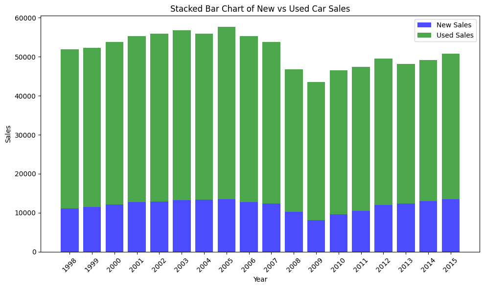

```python
# Plotting
plt.figure(figsize=(10, 6))

# Plot stacked bars
plt.bar(merged_df['DATE'], merged_df['new sales'], label='New Sales', color='b', alpha=0.7)
plt.bar(merged_df['DATE'], merged_df['used sales'], bottom=merged_df['new sales'], label='Used Sales', color='g', alpha=0.7)

# Customize plot
plt.xlabel('Year')
plt.ylabel('Sales')
plt.title('Stacked Bar Chart of New vs Used Car Sales')
plt.xticks(merged_df['DATE'], rotation=45)
plt.legend()

# Show plot
plt.tight_layout()
plt.show()
```

# Continued Data Analysis with Machine Learning

Classification: Use ML model to classify sales based on region

Regression: Use Various Regression models to figure out a functional representation of Total Vehicle Sales per Million versus Auto Tons

> Now we have seen certain trends in the data regarding the relationship between shipping, car price, date, etc. Let's build on these findings via Machine Learning Models to create predictive models to map such relationships in the data.

> > To begin, let us model the relationship between shipping auto tons and total sales, as it would be interesting to predict the state of the car market based on the shipping data.

```python
from sklearn.linear_model import LinearRegression
from sklearn.model_selection import train_test_split
import numpy as np
import matplotlib.pyplot as plt

random_state = 42
np.random.seed(random_state)

linear_model = LinearRegression()
X = np.reshape(filtered_df['Auto Tons'].values, (-1, 1))
y = np.reshape(filtered_df['TOTALSA'].values, (-1, 1))

X_train_auto, X_test_auto, y_train_auto, y_test_auto = train_test_split(X, y, random_state=random_state)
linear_model.fit(X_train_auto, y_train_auto)

y_train_auto_pred = linear_model.predict(X_train_auto)
y_test_auto_pred = linear_model.predict(X_test_auto)
```

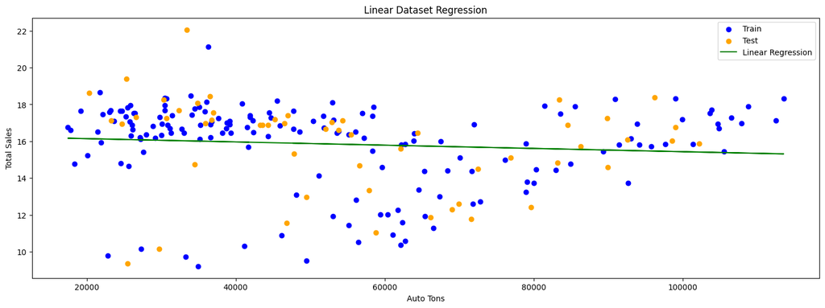

```python
fig, axes = plt.subplots(figsize=(18, 6))

# Linear dataset and model
axes.scatter(X_train_auto, y_train_auto, color='blue', label='Train')
axes.scatter(X_test_auto, y_test_auto, color='orange', label='Test')
axes.plot(X_train_auto, y_train_auto_pred, color='green', label='Linear Regression')
axes.set_xlabel('Auto Tons')
axes.set_ylabel('Total Sales')
axes.set_title('Linear Dataset Regression')
axes.legend()
```

```python
from sklearn.metrics import mean_squared_error, r2_score
# For Linear dataset
# Calculate MSE and R^2 for the linear dataset
mse_linear_train = mean_squared_error(y_train_auto, y_train_auto_pred)
mse_linear_test = mean_squared_error(y_test_auto, y_test_auto_pred)
r2_linear_train = r2_score(y_test_auto, y_test_auto_pred)
r2_linear_test = r2_score(y_train_auto, y_train_auto_pred)

print(f"MSE Train: {mse_linear_train}")
print(f"R2 Train: {r2_linear_train}")
print(f"MSE Test: {mse_linear_test}")
print(f"R2 Test: {r2_linear_test}")
```

```
MSE Train: 5.051458993880311
R2 Train: 0.022374905091218977
MSE Test: 5.9408341708823045
R2 Test: 0.009918859325445117
```

Due to the high variance in data as seen in the above graph, the low R^2 values, combined with the high MSE in the data, it is evident the Linear Regression is NOT a good fit. Instead, we will attempt a Polynomial regression due to the oscillating and "curvy" nature of the data.

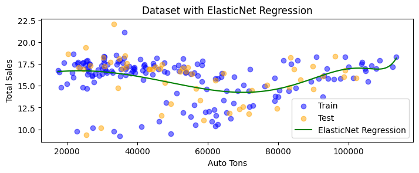

```python
from sklearn.linear_model import Lasso, Ridge, ElasticNet, LinearRegression
from sklearn.preprocessing import PolynomialFeatures
from sklearn.pipeline import make_pipeline

alpha_value = 0.01
model_elastic = make_pipeline(PolynomialFeatures(degree=30), ElasticNet(alpha=alpha_value))
model_elastic.fit(X_train_auto, y_train_auto)

X_auto_dense = np.linspace(X_train_auto.min(), X_train_auto.max(), 400).reshape(-1, 1)
Y_auto_dense_pred_elastic = model_elastic.predict(X_auto_dense)

plt.figure(figsize=(18, 6))

# ElasticNet Regression
plt.subplot(2, 2, 4)
plt.scatter(X_train_auto, y_train_auto, color='blue', label='Train', alpha=0.5)
plt.scatter(X_test_auto, y_test_auto, color='orange', label='Test', alpha=0.5)
plt.plot(X_auto_dense, Y_auto_dense_pred_elastic, color='green', label='ElasticNet Regression')
plt.title('Dataset with ElasticNet Regression')
plt.xlabel('Auto Tons')
plt.ylabel('Total Sales')
plt.legend()
```

## Demographics of Car Sales

It is evident that the car market across the US is widespread, however, seeing differences in the types of cars purchased would be interesting to see among the different regions of the US.

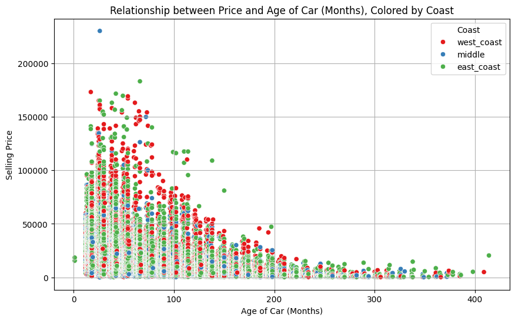

```python
# approximate the age of the car in months
cpf['saleage'] = ((cpf['saledate'].dt.year - cpf['makeyear'] + 1) * 12) + cpf['saledate'].dt.month

# plot the relationship between price and age and color based on coast
import matplotlib.pyplot as plt
import seaborn as sns
plt.figure(figsize=(10, 6))
sns.scatterplot(x='saleage', y='sellingprice', hue='Coast', data=cpf, palette='Set1')
plt.title('Relationship between Price and Age of Car (Months), Colored by Coast')
plt.xlabel('Age of Car (Months)')
plt.ylabel('Selling Price')
plt.grid(True)
plt.legend(title='Coast')
plt.show()
```

Although the data is spread relatively equally throughout the price ranges for each region, we tend to see the West Coast have slightly more expensive cars. We will run a classifier to see if our model can classify the "price bracket" (cheap, middle, or expensive) of a car based on features like make year, saledate, region of the United States, etc.

Note: The code below makes the assumption that a "cheap" car is less than \$10000 and expensive is \$75000 and above.

```python
from sklearn.tree import DecisionTreeClassifier
from sklearn.metrics import accuracy_score

print(cpf.columns)
#X = cpf[['saleage', 'sellingprice', 'makeyear']]
cpf["Coast_Num"] = cpf['Coast'].map({'west_coast': 0, 'middle': 1, 'east_coast': 2})
cpf["Price_Bracket"] = cpf["sellingprice"].apply(lambda x: "Cheap" if x < 10000 else ("Middle" if x < 75000 else "Expensive"))
X = cpf[['saleage', 'Coast_Num', 'makeyear']]
y = cpf['Price_Bracket']

# Split the data into training and testing sets
X_train, X_test, y_train, y_test = train_test_split(X, y, test_size=0.2)
clf = DecisionTreeClassifier()

clf.fit(X_train, y_train)
y_pred = clf.predict(X_test)

accuracy = accuracy_score(y_test, y_pred)
print("Accuracy:", accuracy)
```

```
Index(['makeyear', 'sellingprice', 'saledate', 'mmr', 'state', 'Coast',
       'saleage'],
      dtype='object')
Accuracy: 0.8330374295521382
```

With the help of the Decision Tree, we see that the features of age, region of US, and make year can help to accurately classify the price range of a car relatively accurately. This indicates that these variables are interrelated and are classifiable via classification models.

## Deepdive into Shipping Tons effect on Car Market

Using Linear Regression, we aim to find a fit for the New Car Sales over time.

```
R2 Test: -0.3742500866735896
```

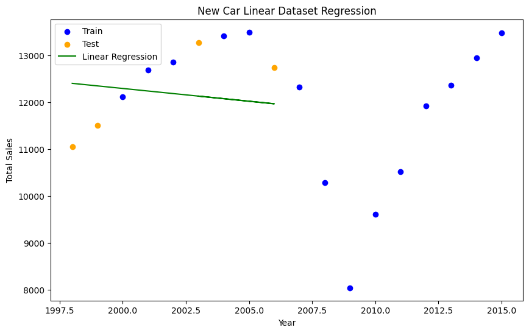

```python
# Previously, saw that new car sales are increasing over time while used car sales are decreasing

#Use AVGCar to Create Regressions with respect to year

X = merged_df['DATE'].values.reshape(-1, 1)
y = merged_df['new sales'].values.reshape(-1, 1)
linear_model = LinearRegression()

X_train, X_test, y_train, y_test = train_test_split(X, y, test_size=0.2, random_state=42)

linear_model.fit(X_train, y_train)
y_pred = linear_model.predict(X_test)

r2_linear_train = r2_score(y_test, y_pred)
print(f"R2 Test: {r2_linear_train}")

#Find point of intersection
plt.figure(figsize=(10, 6))
plt.scatter(X_train, y_train, color='blue', label='Train')
plt.scatter(X_test, y_test, color='orange', label='Test')
plt.plot(X_test, y_pred, color='green', label='Linear Regression')

plt.xlabel('Year')
plt.ylabel('Total Sales')
plt.title('New Car Linear Dataset Regression')
plt.legend()
plt.show()
```

As we can see, the graph represents data that isn't linear and instead is actually more polynomial than we had first thought. That being said, the poor fit of Linear Regression can be seen in our negative R^2 value using this model. However the poor fit can be attributed to the 2008 crash and the years surrounding it from 2006-2011.

Similar to our attempt in representing new car sales, we aim to represent used car sales versus time using Linear Regression here as well.

```
R2 Test: -4.539182059958902
```

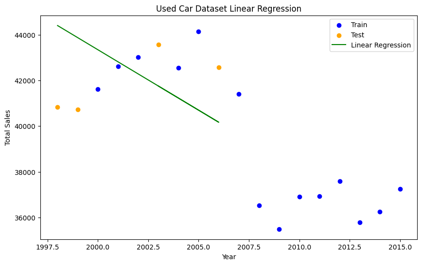

```python
#Similar for used car sales

X = merged_df['DATE'].values.reshape(-1, 1)
y = merged_df['used sales'].values.reshape(-1, 1)
linear_model_used = LinearRegression()

X_train_used, X_test_used, y_train_used, y_test_used = train_test_split(X, y, test_size=0.2, random_state=42)

linear_model.fit(X_train_used, y_train_used)
y_pred_used = linear_model.predict(X_test_used)

r2_linear_train = r2_score(y_test_used, y_pred_used)
print(f"R2 Test: {r2_linear_train}")

#Find point of intersection
plt.figure(figsize=(10, 6))
plt.scatter(X_train_used, y_train_used, color='blue', label='Train')
plt.scatter(X_test_used, y_test_used, color='orange', label='Test')
plt.plot(X_test_used, y_pred_used, color='green', label='Linear Regression')

plt.xlabel('Year')
plt.ylabel('Total Sales')
plt.title('Used Car Dataset Linear Regression')
plt.legend()
plt.show()
```

Although the graph here is more clearly downward than the 'New Car Sales' graph above, the Linear Regression still doesn't represent the data well enough as can be seen with a strong negative R^2 value. There is still much to be desired in terms of finding a good regressioon model that will represent the data better.

This is why in the next two graphs we will be using Polynomial Features on the New and Used car sales in an effort to model an effective function of the data.

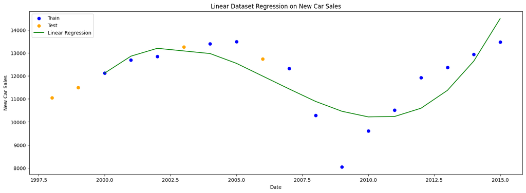

```python
# Running ElasticNET regressions with polynomial features for new and used car sales

# Configuring the models with polynomial features
linear_poly = make_pipeline(PolynomialFeatures(degree=10), LinearRegression())
linear_poly.fit(X_train, y_train)
# Predict on the training data to plot the regression lines
Y_linear_train_pred_poly = linear_poly.predict(X_train)
# Predict on the test data for evaluation
Y_linear_test_pred_poly = linear_poly.predict(X_test)
# Prepare sorted X values for plotting polynomial regression lines
X_linear_train_sorted_idx = np.argsort(X_train.ravel())
X_linear_test_sorted_idx = np.argsort(X_test.ravel())


# Linear dataset and model
fig, axes = plt.subplots(figsize=(18, 6))
axes.scatter(X_train, y_train, color='blue', label='Train')
axes.scatter(X_test, y_test, color='orange', label='Test')
axes.plot(X_train[X_linear_train_sorted_idx], Y_linear_train_pred_poly[X_linear_train_sorted_idx], color='green', label='Linear Regression')
axes.set_title('Linear Dataset Regression on New Car Sales')
axes.set_xlabel('Date')
axes.set_ylabel('New Car Sales')
axes.legend()
```

```python
mse_linear_train_poly = mean_squared_error(y_train, Y_linear_train_pred_poly)
r2_linear_train_poly = r2_score(y_train, Y_linear_train_pred_poly)
print("Evauation Metrics on Training Regression Curve for New Car Sales")
print(f"R2 Test New: {r2_linear_train_poly}")
print(f"MSE Test New: {mse_linear_train_poly}")
```

```
Evauation Metrics on Training Regression Curve for New Car Sales
R2 Test New: 0.64070474022078
MSE Test New: 895999.6593215057
```

Similar to the process with the New Car Sales data, we will be using the Polynomial Features to fit the data and incorporate more of the data's curved shape.

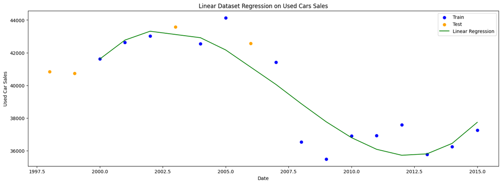

```python
# Running ElasticNET regressions with polynomial features for new and used car sales

# Configuring the models with polynomial features
linear_poly = make_pipeline(PolynomialFeatures(degree=7), LinearRegression())
linear_poly.fit(X_train_used, y_train_used)
# Predict on the training data to plot the regression lines
Y_linear_train_pred_poly_used = linear_poly.predict(X_train_used)
# Predict on the test data for evaluation
Y_linear_test_pred_poly_used = linear_poly.predict(X_test_used)
# Prepare sorted X values for plotting polynomial regression lines
X_linear_train_sorted_idx_used = np.argsort(X_train_used.ravel())

# Linear dataset and model
fig, axes = plt.subplots(figsize=(18, 6))
axes.scatter(X_train_used, y_train_used, color='blue', label='Train')
axes.scatter(X_test_used, y_test_used, color='orange', label='Test')
axes.plot(X_train_used[X_linear_train_sorted_idx_used], Y_linear_train_pred_poly_used[X_linear_train_sorted_idx_used], color='green', label='Linear Regression')
axes.set_xlabel('Date')
axes.set_ylabel('Used Car Sales')
axes.set_title('Linear Dataset Regression on Used Cars Sales')
axes.legend()
```

```python
mse_linear_train_poly_used = mean_squared_error(y_train_used, Y_linear_train_pred_poly_used)
r2_linear_train_poly_used = r2_score(y_train_used, Y_linear_train_pred_poly_used)
print("Evauation Metrics on Training Regression Curve for Used Car Sales")
print(f"R2 Test New: {r2_linear_train_poly_used}")
print(f"MSE Test New: {mse_linear_train_poly_used}")
```

```
Evauation Metrics on Training Regression Curve for Used Car Sales
R2 Test New: 0.8384027371676614
MSE Test New: 1510397.5030500323
```

# Insight & Policy Decision

Through our usage of machine learning models and statistical methods, we were able to analyze Maryland Port Data and car sales over two decades of data. Through our investigation, we can conclude a negligible relation between auto sales and Maryland Port Data. This conclusion does not lead us to believe there is a correlation between the two variables but instead that there are unseen variables that could have a greater correlation. On the other hand, using an ANOVA test, we can conclude that there is a statistical significance in the prices increasing from the east coast to the west coast. We believe that this is due to the shipping costs that incur as vehicles are transported over mainland America. Overall, we believe that this topic requires further research and more data to be able to conduct more tests and obtain different conclusions. Considering the recent bridge collapse in Baltimore, we would need more time and data to fully explore some of the ramifications that it caused not only on the East Coast but also on the west coast as well.